# MultiResponse_eval

2024-11-25

```r
library(MASS)
library(ggplot2)
library(tidyr)
library(dplyr)
library(SingleCellExperiment)
library(MANOVA.RM)
library(tibble)
library(tidyverse)
library(limma)
```

## Adjusted Rand Index with scSTMseq and Seurat

scSTMseq has a much better ARI compared to seurat. Note that seurat has about 900 files ran, while scSTMseq has only about 132 files ran (since scSTMseq is slow)

```r
ari <- read.csv("/proj/milovelab/wu/scLDAseq/res/1MultiSample_MultiResponse_Simulation/scSTMseq_ARI_MultiResponse_Batch_CancerCell_scSTM_Pooled_Content_Sample_Prevalence_Time.csv")

ari <- ari %>%
  as.data.frame() %>%
  dplyr::mutate(scSTMTypeNumeric = case_when(
    modelType == "NullModel" ~ 0,
    grepl("HighVar", modelType) ~ as.numeric(sub("HighVar", "", modelType))
  ))
```

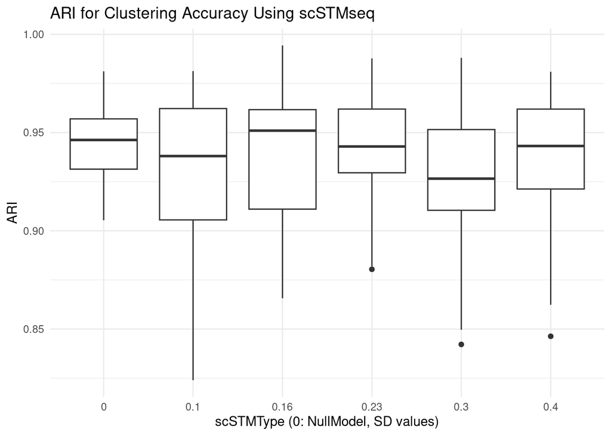

```r
# Create the box plot
ggplot(ari, aes(x = factor(scSTMTypeNumeric), y = pooled_scSTMseq)) +
  geom_boxplot() +
  labs(
    x = "scSTMType (0: NullModel, SD values)",
    y = "ARI",
    title = "ARI for Clustering Accuracy Using scSTMseq"
  ) +
  theme_minimal()
```

```r
ari <- read.csv("/proj/milovelab/wu/scLDAseq/res/1MultiSample_MultiResponse_Simulation/seurat_ARI.csv")

ari <- ari %>%
  as.data.frame() %>%
  dplyr::mutate(scSTMTypeNumeric = case_when(
    modelType == "NullModel" ~ 0,
    grepl("HighVar", modelType) ~ as.numeric(sub("HighVar", "", modelType))
  ))
```

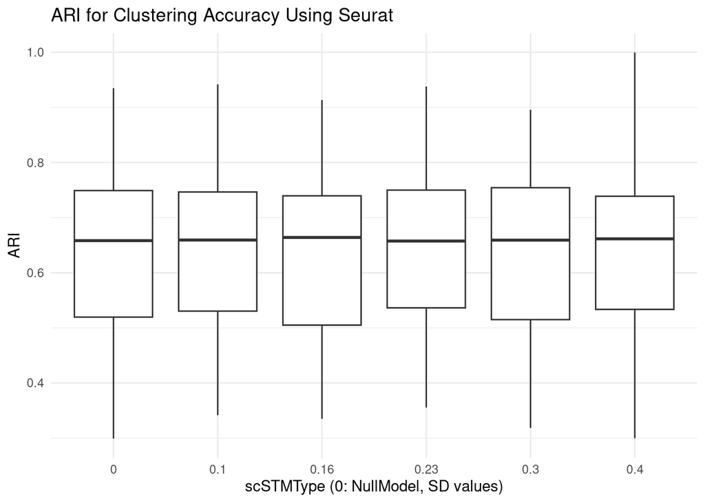

```r
ggplot(ari, aes(x = factor(scSTMTypeNumeric), y = ARI)) +
  geom_boxplot() +
  labs(
    x = "scSTMType (0: NullModel, SD values)",
    y = "ARI",
    title = "ARI for Clustering Accuracy Using Seurat"
  ) +
  theme_minimal()
```

## MANOVA.RM + scSTMseq

Based on the simulation setup, we should observe increasing power on the interaction term of response and time when effect size increases. However, we could see that this analysis has pratically no power. However, from ARI, we know our clustering results were solid.

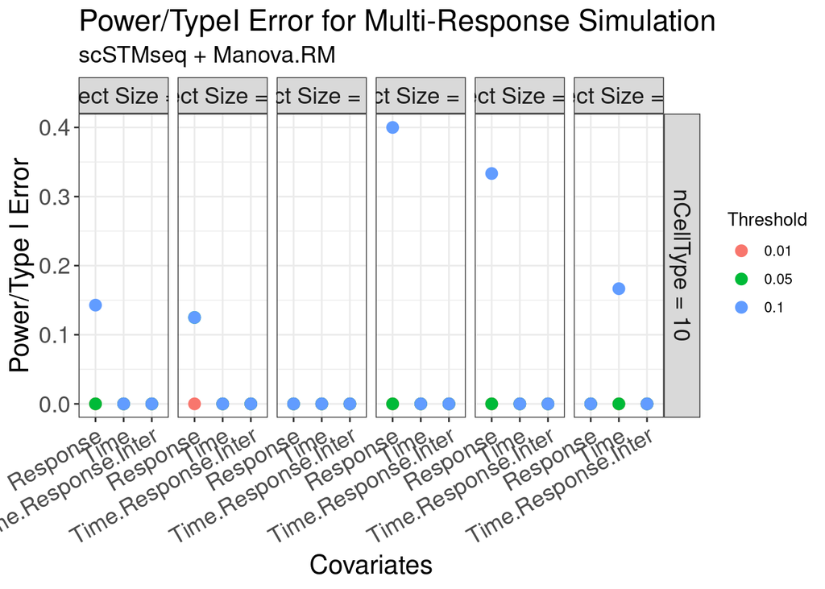

```r
dat <- readRDS("/proj/milovelab/wu/scLDAseq/res/1MultiSample_MultiResponse_Simulation/Manova_pValue_nSample20_Pooled_Content_Sample_Prevalence_Time.rds")
pValue50 <- lapply(names(dat), function(name) {
  data <- dat[[name]]
  temp <- data.frame(
    nCellType = unlist(strsplit(name, "_"))[1],
    EffectSize = unlist(strsplit(name, "_"))[3],
    Response = quantile(data$Response, probs = 0.50),
             Time = quantile(data$Time, probs = 0.50),
             `Response:Time` = quantile(data$`Response:Time`, probs = 0.50)
    )
  return(temp)
})
pValue50 <- do.call(rbind, pValue50)
pValue50 <- pValue50 %>%
  mutate(
    nCellType = as.numeric(sub("nCellType", "", nCellType)),
    EffectSize = case_when(
      EffectSize == "NullModel" ~ 0,
      grepl("HighVar", EffectSize) ~ as.numeric(sub("HighVar", "", EffectSize))
    ))

threshold <- c(0.01, 0.05, 0.1)
topic_plot <- plot_data_generate(threshold, pValueList = pValue50, by_group = "EffectSize")
topic_plot <- topic_plot %>%
  mutate(Threshold = as.factor(Threshold)) %>%
  dplyr::rename("Time" = "time_sig_proportion",
         "Response" = "response_sig_proportion",
         "Time.Response.Inter" = "interaction_sig_proportion") %>%
  pivot_longer(cols = c("Time", "Response", "Time.Response.Inter"), names_to = "Covariate", values_to = "Power")

ggplot(topic_plot, aes(x = Covariate, y = Power, color = Threshold, group = Threshold)) +
  geom_point(size = 3) +
  facet_grid(nCellType~EffectSize,
             labeller = labeller(EffectSize = function(x) paste("Effect Size =", x),
                                 nCellType = function(x) paste("nCellType =", x))) +
  labs(title = "Power/TypeI Error for Multi-Response Simulation",
       subtitle = "scSTMseq + Manova.RM",
       x = "Covariates",
       y = "Power/Type I Error") +
  theme_bw() +
  theme(
    plot.title = element_text(size = 18, hjust = 0),  # Left-align title
    plot.subtitle = element_text(size = 14, hjust = 0),  # Left-align subtitle
    axis.title.x = element_text(size = 16),  # Increase X axis title size
    axis.title.y = element_text(size = 16),  # Increase Y axis title size
    axis.text.x = element_text(size = 14, angle = 30, hjust = 1),
    axis.text.y = element_text(size = 14),   # Increase Y axis labels size
    strip.text = element_text(size = 14)  # Increase facet label text size
  )
```

## MANOVA + Simulated Data

To troubleshoot what we observed in the previous section, we try to implement MANOVA.RM directly on simulated data (skipping scSTMseq). Again, focusing on the interaction term, we could see that the power is decent, following a pattern similar to what we obsvered in multiple response setting.

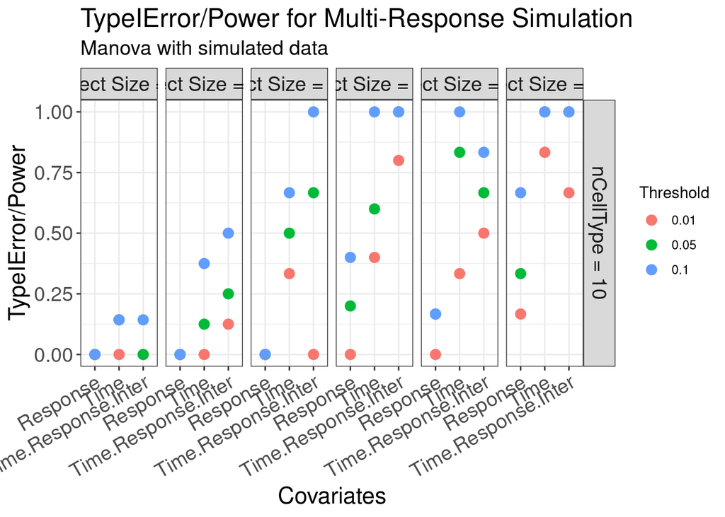

```r
dat <- readRDS("/proj/milovelab/wu/scLDAseq/res/1MultiSample_MultiResponse_Simulation/Manova_sims_nSample20_Pooled_Content_Sample_Prevalence_Time.rds")

dat <- do.call(rbind, dat)
dat <- dat %>%
  as.data.frame() %>%
  mutate(
    nCellType = as.numeric(sub("nCellType", "", sapply(strsplit(rownames(dat), "_"), `[`, 1))),
    EffectSize = sapply(strsplit(rownames(dat), "_"), `[`, 3))
dat <- dat %>%
  mutate(EffectSize = case_when(
      EffectSize == "NullModel" ~ 0,
      grepl("HighVar", EffectSize) ~ as.numeric(sub("HighVar", "", EffectSize))
    ))

threshold <- c(0.01, 0.05, 0.1)
topic_plot <- plot_data_generate(threshold, pValueList = dat, by_group = "EffectSize")
topic_plot <- topic_plot %>%
  mutate(Threshold = as.factor(Threshold)) %>%
  dplyr::rename(Time = time_sig_proportion,
         Response = response_sig_proportion,
         Time.Response.Inter = interaction_sig_proportion) %>%
  pivot_longer(cols = c("Time", "Response", "Time.Response.Inter"), names_to = "Covariate", values_to = "Power")

ggplot(topic_plot, aes(x = Covariate, y = Power, color = Threshold, group = Threshold)) +
  geom_point(size = 3) +
  facet_grid(nCellType~EffectSize,
             labeller = labeller(EffectSize = function(x) paste("Effect Size =", x),
                                 nCellType = function(x) paste("nCellType =", x))) +
  labs(title = "TypeIError/Power for Multi-Response Simulation",
       subtitle = "Manova with simulated data",
       x = "Covariates",
       y = "TypeIError/Power") +
  theme_bw() +
  theme(
    plot.title = element_text(size = 18, hjust = 0),  # Left-align title
    plot.subtitle = element_text(size = 14, hjust = 0),  # Left-align subtitle
    axis.title.x = element_text(size = 16),  # Increase X axis title size
    axis.title.y = element_text(size = 16),  # Increase Y axis title size
    axis.text.x = element_text(size = 14, angle = 30, hjust = 1),
    axis.text.y = element_text(size = 14),   # Increase Y axis labels size
    strip.text = element_text(size = 14)  # Increase facet label text size
  )
```

## Seurat + Propeller

Then is the problem with scSTMseq? To investigate more, I used propeller, particularly limma with sample block effect, with seurat clustering reuslts. The contrast is set to be time2 versus time1 for response group and non-response group respectively. We should expect significant changes in cell proportion in response group but not in non-response group.

We can see that while the non-response group controls well, we are observing the same issue as the MANOVA.RM with scLDAseq data. The algorithm essentially has no power.

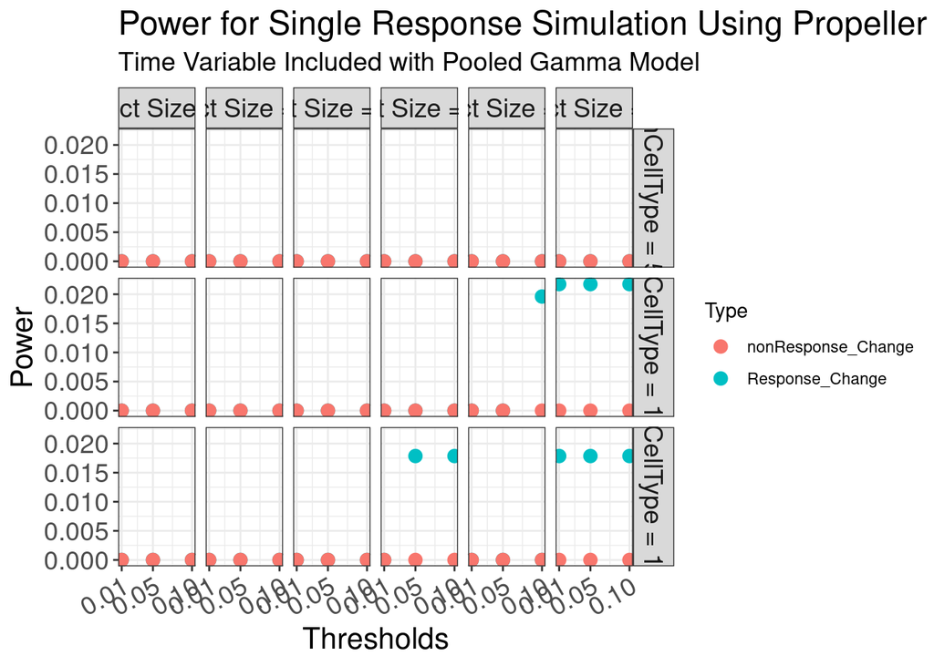

```r
dat <- readRDS("/proj/milovelab/wu/scLDAseq/res/1MultiSample_MultiResponse_Simulation/propeller_BlockSampleseurat.rds")
threshold <- c(0.01, 0.05, 0.1)
dat.fdr <- lapply(names(dat), function(name){
  x <- dat[[name]]

  Response_Change <- sapply(threshold, function(t) x$Response_Change < t)
  Response_Change <- colSums(Response_Change) != 0

  nonResponse_Change <- sapply(threshold, function(t) x$nonResponse_Change < t)
  nonResponse_Change <- colSums(nonResponse_Change) != 0
  temp <- rbind(Response_Change, nonResponse_Change)
  colnames(temp) <- threshold
  return(temp)
})
names(dat.fdr) <- names(dat)

topic_plot <- do.call(rbind, lapply(names(dat.fdr), function(name) {
  df <- dat.fdr[[name]] %>% as.data.frame()
  df$Type <- rownames(df)
  df$EffectSize <- ifelse(unlist(strsplit(name, "_"))[3] == "NullModel", 0 ,as.numeric(sub(".*HighVar([0-9.]+)$", "\\1", name)))
  df$nCellType <- as.numeric(n_cell_types <- sub(".*nCellType(\\d+)_.*", "\\1", name))
  return(df)
}))

topic_plot <- topic_plot %>%
  group_by(EffectSize, nCellType, Type) %>%
  summarize(Power_0.01 = mean(`0.01`),
            Power_0.05 = mean(`0.05`),
            Power_0.1 = mean(`0.1`),
            .groups = "drop")
topic_plot <- topic_plot %>%
  pivot_longer(cols = starts_with("Power"), names_to = "Threshold", values_to = "Power") %>%
  mutate(Threshold = as.numeric(gsub("Power_", "", Threshold)))

ggplot(topic_plot, aes(x = Threshold, y = Power, color = Type, group = Type)) +
  geom_point(size = 3) +
  facet_grid(nCellType~EffectSize,
             labeller = labeller(EffectSize = function(x) paste("Effect Size =", x),
                                 nCellType = function(x) paste("nCellType =", x))) +
  labs(title = "Power for Single Response Simulation Using Propeller",
       subtitle = "Time Variable Included with Pooled Gamma Model",
       x = "Thresholds",
       y = "Power") +
  theme_bw() +
  scale_x_continuous(breaks = threshold) +  # Ensure proper thresholds on X axis
  theme(
    plot.title = element_text(size = 18, hjust = 0),  # Left-align title
    plot.subtitle = element_text(size = 14, hjust = 0),  # Left-align subtitle
    axis.title.x = element_text(size = 16),  # Increase X axis title size
    axis.title.y = element_text(size = 16),  # Increase Y axis title size
    axis.text.x = element_text(size = 14, angle = 30, hjust = 1),
    axis.text.y = element_text(size = 14),   # Increase Y axis labels size
    strip.text = element_text(size = 14)  # Increase facet label text size
  )
```